# Zeitabhängige Diffusion als Anfangswertproblem

b) Implementieren Sie die Lösungsdarstellunsformel für Poissongleichung $(\Phi*f)(x)$ und für den Anfangswertproblem der instationären Diffusionsgleichung $(\Psi*u_0)(x,t)$ mithilfe numerischen Integration (z.B. Trapezregel). Wählen Sie beliebige beschränkte Quellfunktion $f$ bzw. Anfangsbedingung $u_o$ mit kompakten Träger.

### Lösung der Poissongleichung auf $\mathbb{R}^2$

$$-\Delta u(x)=f(x),$$

Voraussetzung: $f$ hat einen kompakten (beschränkten) Träger innerhalb des Gebietes $D \subset \mathbb{R}^2$.

Definiere zuerst die Funktion der rechten Seite, in den nachfolgenden Zellen wird diese Funktion abgerufen:

##### Quellfunktion 1

```matlab
function wert=Quellfunktion(x,y)
  if sqrt((x.-1.0).^2+(y.-1).^2)<=0.15 wert=1;
    else wert=0;
  endif
endfunction
```

```matlab
% clear all loescht alle  bisher definierten Variablen
%clear all;
step=0.03;
 X=[0:step:2];
 Y=[0:step:2];
 [x,y]=meshgrid(X,Y);
```

Speichere die Funktionswerte von $f$ in jedem Gitterpunkt, $f(x(j,i),y(j,i))$, in eine Matrix.

```matlab
for i=1:(length(X))
for j=1:(length(Y))
   f(j,i)=1*Quellfunktion(x(j,i),y(j,i));
 endfor
endfor
```

### Implementierung der Poissonformel

Bemerkung: da $f$ kompakten Träger in $D$ hat, ist $$\int_{\mathbb{R}^2}\Phi(x^\star-x)f(x)dx=\int_{D}\Phi(x^\star-x)f(x)dx=\int_{0}^2\int_{0}^2\Phi(x^\star-x, y^\star-y)f(x,y)dx dy.$$ Zuerst werden $\Phi(x^\star-x)$ - die Werte der Fundamentalfunktion mit um ein festes $x^\star \in D_h$ verschobenem Argument für jeden Gitterpunkt $x(j,i),y(j,i)$ gebildet und in Matrix 'phi' gespeichert.
Der feste $x^\star$ wird als Matrix mit konstanten Einträgen definiert, damit die Differenz der Funktionsargumente als Differenz der Matrizen möglich ist.
Nacheinander werden in der Schleife alle Gitterpunkte zum $x^\star$ ausgewählt.

Wenn $x^\star\equiv x$, setzen wir $\Phi(x^\star-x)=0$ (dadurch wird der eine Punkt der Singularität aus dem Integral rausgeschnitten, was den Wert des Integralls nicht beeinflußt, da es sich um eine Menge vom Maß Null handelt.)

Zum Schluss wird das doppelte Integral mit Trapezregel berechnet.  
Dabei ist $u(x)=\Phi(x) := \left\{ \begin{array}{l} -\frac {1} {2 \pi} \ln {\|x\|}\ ,&n = 2\\ \frac {1} {\omega_n} \frac {1} {\|x\|^{n-2}}=\frac {3} {4 \pi} \frac {1} {\|x\|^{n-2}}\ ,&n \geq3\\ \end{array} \right. $

```matlab
for i=1:(length(X))
for j=1:(length(Y))
xstar=x(j,i)*ones(length(Y),length(X));
ystar=y(j,i)*ones(length(Y),length(X));
% Phi mit verschobenem Argument:
phi=-log(sqrt((xstar.-x).^2+(ystar.-y).^2))/(2*pi);
phi(j,i)=0;

%numerische Integration
I(j,i) = trapz(Y,trapz(X,phi.*f,2));
 endfor
endfor
```

Graphische Ausgaben

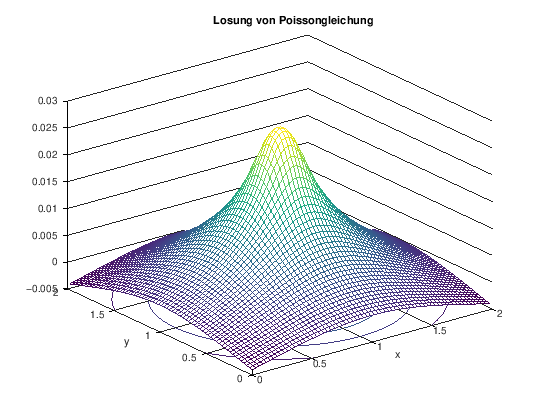

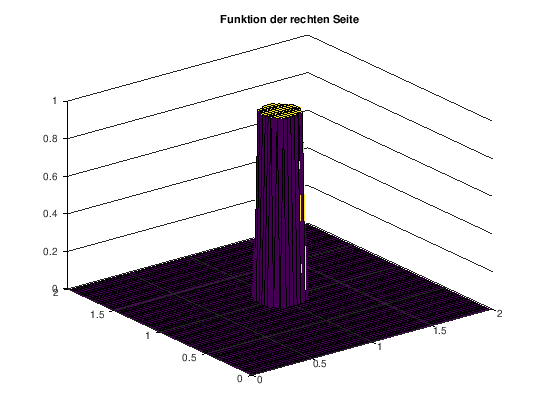

```matlab
figure 1
meshc(x,y,I)
grid on
title ('Losung von Poissongleichung')
xlabel('x')
ylabel ('y')

figure 2
surfc(x,y,f)
title ('Funktion der rechten Seite')
```

##### Ergebnis

- Lösung zeigt die Verteilung der Teilchen im Raum.
- Hierbei handelt es sich um eine inhomogene Diffusionsgleichung. Mit der Quellfunktion der rechten Seite werden Teilchen in das System gespeist.
- Bezogen auf Corona würden hier (mithilfe der Quellfunktion) einmal Infizierte in eine Umgebung eintreten.  
  An der Stelle, an der die Infizierten in das System eintreten, ist die Infektionszahl und das Infektionsrisiko hoch. In der Realität würde dies wenig Sinn machen, da die Infizierten die Infektion nicht an gesunde Menschen weitergeben würden.
- Da es sich um eine stationäre Diffusionsgleichung handelt, wird die Infektion nicht weiterverbreitet.